# Assignment 3, Task 3

Catherine Takata

11/2/2020

```r
knitr::opts_chunk$set(echo = TRUE)
library(tidyverse)
library(here)
library(janitor)
library(lubridate)
library(kableExtra)
```

#### Read in data set for local use

```r
urchins <- read.csv(here("data", "urchins.csv"))
```

### Section 1

- Use a faceted histogram() and boxplot() to initially explore data through visualization. These function will help compare the distribution of sizes of purple and red urchins.
- First, to practice “tidy” methods, convert the column names to lowercase using the clean_names() of the janitor package.

```r
urchins_clean <- urchins %>%
  clean_names()
```

#### Histogram

- Using the “tidy” dataset, we can use geom_histogram to create a histogram of the common name and size.
- The histogram will visually represent the number of urchins in each category at each urchin diamter meausrement.
- Using facet_wrap() will visually create a seperate group based on the two different common names.

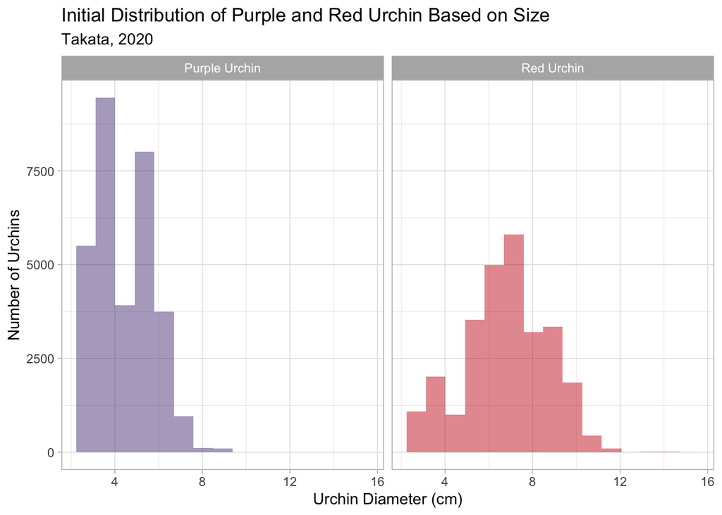

```r
ggplot(data = urchins_clean, aes(x = size, fill = common_name)) +
  geom_histogram(bins = 15, alpha = 0.5, show.legend = FALSE) +
  facet_wrap(~common_name) +
  labs(title = "Initial Distribution of Purple and Red Urchin Based on Size",
       subtitle = "Takata, 2020",
       x = "Urchin Diameter (cm)",
       y = "Number of Urchins") +
  scale_fill_manual(values = c("mediumpurple4", "firebrick3")) +
  theme_light()
```

#### The histogram vary in size/distribution/tendency for purple and red urchins. The purple urchins seem to be postivley skewed, with a tail forming toward the opposing side. The means concentrate at the lower numbers indicating a lower tendency. The red urchins, on the other hands, have a more normal distribution, following a bell shape. Their values have a central tendency, hovering around the middle of the distribution with a larger SD and “squattier” distribution.

#### Boxplot

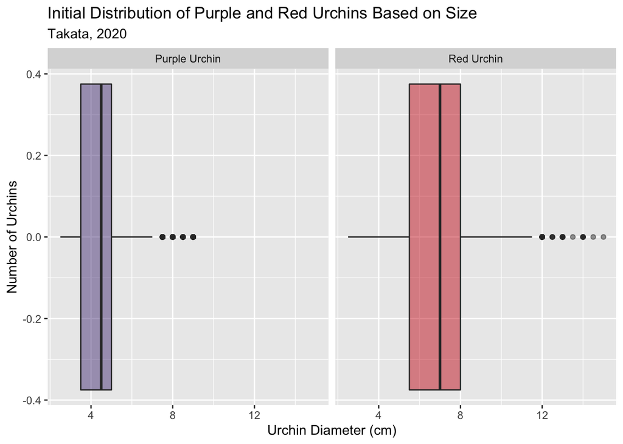

```r
ggplot(data = urchins_clean, aes(x = size, fill = common_name)) +
  geom_boxplot(alpha = 0.5, show.legend = FALSE) +
  facet_wrap(~common_name) +
  labs(title = "Initial Distribution of Purple and Red Urchins Based on Size",
       subtitle = "Takata, 2020",
       x = "Urchin Diameter (cm)",
       y = "Number of Urchins") +
  scale_fill_manual(values = c("mediumpurple4", "firebrick3"))
```

### Section 1 ii.

#### Statistics Table

- Create a summary table that contains mean, median, sd, and sample size for purple + red urchins

```r
urchin_sum_stats <- urchins_clean %>%
  group_by(common_name) %>%
  summarize(mean = mean(size, na.rm = TRUE),
            median = median(size, na.rm = TRUE),
            sd = sd(size, na.rm = TRUE),
            sample_size = n(),
            .groups = 'drop')

kbl(urchin_sum_stats) %>%
  kable_styling()
```

| common_name | mean | median | sd | sample_size |
| --- | --- | --- | --- | --- |
| Purple Urchin | 4.469797 | 4.5 | 1.175264 | 31805 |
| Red Urchin | 6.776489 | 7.0 | 1.891343 | 27408 |

### Section 2 i.

- Explore purple urchin counts by site and year
- Convert data to DATE class, add columns to existing dataset with wrangled data

#### Next, create a stored subset of the urchins data called purple_urchins

- Use filter() to isolate the observations for just the purple urchins
- Using mutate() add a new column based on the date class
- case_when() can be used as an “OR” statement, in this scenario, if “site” contains “an abbrviation”NAPL" OR “AQUE” OR “CARP” (etc), print it in a new mutated column.

```r
urchins_clean <- urchins_clean %>%
  mutate(date = mdy(date))

class(urchins_clean$date)
```

```
## [1] "Date"
```

```r
purple_urchins <- urchins_clean %>%
  filter(common_name == "Purple Urchin") %>%
  mutate(year = year(date)) %>%
  mutate(site_full = case_when(
    site %in% "NAPL" ~ "Naples Reef",
    site %in% "AQUE" ~ "Arroyo Quemado Reef",
    site %in% "CARP" ~ "Carpinteria Reef",
    site %in% "MOHK" ~ "Mohawk Reef",
    site %in% "IVEE" ~ "Isla Vista Reef"
  ))
```

### Section 2 ii.

#### Summary table containing the total number of purple urchins by site + year

- Count() will provide the number of observations per parameter

```r
sum_purp_urchins <- purple_urchins %>%
  count(site_full, year)
```

#### Exploratory graph of purple urchin summary

- Geom_col() can be used to represent the number of urchins per year
- Like before, use facet_wrap() to distinguish between the five different sites

[figure not shown]

```r
ggplot(data = sum_purp_urchins, aes(x = year, y = n, fill = site_full)) +
  geom_col(show.legend = FALSE) +
  #geom_histogram(bins = 30, alpha = 0.5, show.legend = FALSE) +
  facet_wrap(~site_full) +
  labs(title = "Mean Annual Purple Urchin Population Per Site",
       subtitle = "Takata 2020",
       x = "Year",
       y = "Number of Urchins")
```